# Interpreting Machine Learning Models - Variable Importance

Craig A. Sloss

2023-05-14

# Introduction and Setup

Settings for this notebook:

- Code will be printed along with the outcome of running that code
- Turn off scientific notation

Load packages used in this notebook. Please ensure that you have run the script 0a_install_packages.R prior to running this code chunk.

```r
library(tidyverse)
library(DALEX)
library(xgboost)
```

Load the dataset that was prepared in the notebook 0b_data_preparation.Rmd, and preview it:

```r
severity_modelling_data = readRDS("../data/severity_modelling_data.rds")
severity_modelling_data %>% head()
```

```
##           IDpol  OccurDate Payment IDclaim  Guarantee Year DrivAge DrivGender
## 1 70100084.100a 2003-01-01     104    7201 Windscreen 2003      31          M
## 2  80100041.10b 2003-01-01     628    6995        TPL 2003      46          F
## 3 90105222.100a 2003-01-01     468    6876        TPL 2003      30          M
## 4 90109476.101a 2003-01-01    4373    6905     Damage 2003      29          M
## 5 90131675.100a 2003-01-01     145    7366 Windscreen 2003      28          M
## 6 90133465.100a 2003-01-01     239    7144 Windscreen 2003      32          M
##   MaritalStatus BonusMalus LicenceNb     PayFreq          JobCode VehAge
## 1    Cohabiting         60         2 Half-yearly Private employee      1
## 2       Married         50         2      Annual Private employee      8
## 3    Cohabiting         72         5      Annual Private employee      4
## 4    Cohabiting         64         2 Half-yearly Private employee      6
## 5       Unknown         76         1      Annual          Unknown     10
## 6       Unknown         64         1 Half-yearly          Unknown      2
##      VehClass VehPower  VehGas               VehUsage                    Garage
```

[output cut: 20 more lines]

# Fit Sample Models

Create a list of all predictors available in the data:

```r
full_predictor_set = c("DrivAge",
                       "DrivGender",
                       "MaritalStatus",
                       "BonusMalus",
                       "PayFreq",
                       "JobCode",
                       "VehAge",
                       "VehClass",
                       "VehPower",
                       "VehGas",
                       "VehUsage",
                       "Garage",
                       "Area",
                       "Marketing")
```

This is a convenience function that will fit a Gradient Boosted Machine, using the xgboost package, given a list of predictors. The model is fit using the severity modelling dataset loaded above. Because the purpose of this work is to create sample models that can be used to illustrate the use of the DALEX package, these models are not tuned or validated on holdout data. (Note that by not tuning the hyperparameters, this ensures they are the same for all models being compared.) The function outputs the model along with the data and response used to fit the model, as these are needed later.

```r
fit_gbm = function(variable_list) {
  formula = paste0("Payment ~ 0 + ", paste0(variable_list, collapse = " + ")) %>% as.formula
  xgb_response = severity_modelling_data$Payment
  xgb_matrix = model.matrix(formula, severity_modelling_data)
  sample_model = xgboost(data = xgb_matrix,
                         label = xgb_response,
                         max_depth = 2,
                         eta = 0.01,
                         nrounds = 60)
  return(list(model = sample_model, data = xgb_matrix, response = xgb_response))
}
```

```r
sample_model_full = fit_gbm(full_predictor_set)
```

## Remove-and-Compare Approach

```r
sample_model_no_driver_age = fit_gbm(setdiff(full_predictor_set, "DrivAge"))
sample_model_no_veh_age = fit_gbm(setdiff(full_predictor_set, "VehAge"))
```

# Variable Importance

## Using DALEX

The first step in using DALEX is to create an “explain” object, based on the model, data, and response:

```r
gbm_explainer = explain(model = sample_model_full$model,
                        data = sample_model_full$data,
                        y = sample_model_full$response)
```

```
## Preparation of a new explainer is initiated
##   -> model label       :  xgb.Booster  (  default  )
##   -> data              :  9246  rows  60  cols
##   -> target variable   :  9246  values
##   -> predict function  :  yhat.default will be used (  default  )
##   -> predicted values  :  No value for predict function target column. (  default  )
##   -> model_info        :  package Model of class: xgb.Booster package unrecognized , ver. Unknown , task regression (  default  )
##   -> predicted values  :  numerical, min =  295.4536 , mean =  543.0942 , max =  10720.3
##   -> residual function :  difference between y and yhat (  default  )
##   -> residuals         :  numerical, min =  -9996.527 , mean =  657.7421 , max =  622172.7
##   A new explainer has been created!
```

The model_parts function is used to produce permutation importance results. The argument “N” is the size of the sample used for variable importance; if it is NULL then the entire dataset is used. (This is reasonable for such a small dataset such as the one in this case study, but for larger datasets we would want to specify a number of observations here so that the calculation does is not too time-consuming.)

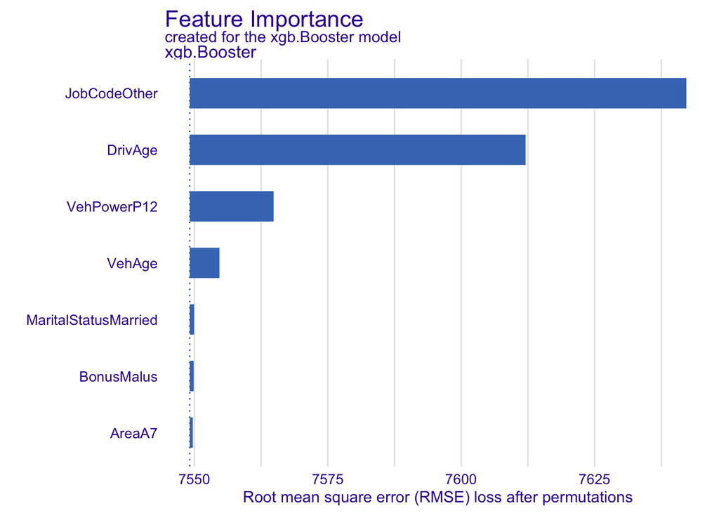

```r
sample_model_importance = model_parts(gbm_explainer, type = "variable_importance", N = NULL)
plot(sample_model_importance, max_vars = 7, show_boxplots = FALSE)
```

## Using xgboost built-in importance measure

The xgboost package also has a bulit-in importance measure that is calculated, while the model is being fit, based on the improvement in performance attributable to a variable at each iteration of the fitting algorithm, rather than using permutation importance. This has the advantage of being faster, but its limitation is that it cannot be used on models other than xgboost models.

```r
xgb.importance(model = sample_model_full$model)
```

```
##                 Feature        Gain        Cover  Frequency
## 1:              DrivAge 0.595406643 0.0059845699 0.22222222
## 2:          VehPowerP12 0.170738734 0.0022442137 0.08333333
## 3:         JobCodeOther 0.161045733 0.5000000000 0.33333333
## 4:               VehAge 0.051637157 0.0007480712 0.02777778
## 5:           BonusMalus 0.007994864 0.1800418199 0.12222222
## 6: MaritalStatusMarried 0.007448153 0.1718581008 0.11666667
## 7:               AreaA7 0.005728716 0.1391232245 0.09444444
```